# Data Analysis and Study of Melting Point Data

September 14, 2021

Abstract

This document provides data analysis and information about melting point data including data cleaning, linear regression, and BIC score comparison analysis.

## Checking for Missing Data

Next, missing data must be accounted for. These commands check for which rows have missing data and then which columns those rows appear in.

```r
#
# Check for missing data
missingData <- ifelse(complete.cases(meltingPoints) == TRUE, 1, 0)
paste("There are", dim(meltingPoints)[1]-sum(missingData), "rows with missing data.")
```

```
## [1] "There are 13 rows with missing data."
```

```r
#
# Since there is missing data we must check which columns have missing data
missingDataCol <-colnames(meltingPoints)[apply(meltingPoints, 2, anyNA)]
paste0("The following columns have missing data: ", missingDataCol)
```

```
## [1] "The following columns have missing data: energy"
```

## Filling in Missing Data

Now knowing that the energy data is numerical, we can replace the missing data with the mean of existing data. I used these commands:

```r
#
# Replace data with the mean of existing data
meltingPoints$energy <- ifelse(is.na(meltingPoints$energy), round(mean(meltingPoints$energy, na.rm=TRUE),0), meltingPoints$energy)
```

## Making a Table of the Distribution

The first table in the article shows the characterization of the 4173 compounds, showing the maximum, minimum, mean, standard deviation, 1st quartile, median, and 3rd quartile of the most important variables. To create this table, I created a vector for each measure of distribution. For example, I created a vector for minimum, containing the minimum of each variable (melting point, molar mass, etc.) as well as a vector for maximum, and so on. I combined these vectors into a data frame called “dataDist”. I transposed this data frame so that it matched the format of the table in the article and then renamed the new columns. Also, where the article references the 2nd quartile, I interpreted as the median which is why I used the median function to calculate the values for the median vector. It should be noted that I used the “quantile” command to calculate the 1st and 3rd quartile values, but I decided not to include the command (just the actual values) in this prompt to make this lengthy segment of code slightly more readeable.

```r
#
# Creating vectors for each measure of data distribution
minimum <- c(round(min(meltingPoints$mp),1), round(min(meltingPoints$molar.mass),1), round(min(meltingPoints$heavy.atoms),1), round(min(meltingPoints$logP),1), round(min(meltingPoints$refractivity), 1), round(min(meltingPoints$dipole.moment),1))
maximum <- c(round(max(meltingPoints$mp),1), round(max(meltingPoints$molar.mass),1), round(max(meltingPoints$heavy.atoms),1), round(max(meltingPoints$logP),1), round(max(meltingPoints$refractivity), 1), round(max(meltingPoints$dipole.moment),1))
mean <- c(round(mean(meltingPoints$mp),1), round(mean(meltingPoints$molar.mass),1), round(mean(meltingPoints$heavy.atoms),1), round(mean(meltingPoints$logP),1), round(mean(meltingPoints$refractivity), 1), round(mean(meltingPoints$dipole.moment),1))
standard.deviation <- c(round(sd(meltingPoints$mp),1), round(sd(meltingPoints$molar.mass),1), round(sd(meltingPoints$heavy.atoms),1), round(sd(meltingPoints$logP),1), round(sd(meltingPoints$refractivity), 1), round(sd(meltingPoints$dipole.moment),1))
firstQuartile <- c(118, 243.3, 17, 2.2, 6.6, 2.4)
median <- c(round(median(meltingPoints$mp),1), round(median(meltingPoints$molar.mass),1), round(median(meltingPoints$heavy.atoms),1), round(median(meltingPoints$logP),1), round(median(meltingPoints$refractivity), 1), round(median(meltingPoints$dipole.moment),1))
thirdQuartile <- c(210.5, 376.5, 27, 4.6, 10.2, 5.5)
#
# data frame of data distribution
dataDist <- data.frame(minimum, maximum, mean, standard.deviation, firstQuartile, median, thirdQuartile)
dataDist <- t(dataDist)
colnames(dataDist) <-c("meltingPoint/C", "molecular weight/g/mol", "number of heavy atoms", "SlogP", "molar refractivity/cm3", "dipole moment (AMI)/debye")
dataDist
```

```
##                    meltingPoint/C molecular weight/g/mol number of heavy atoms
## minimum                      14.0                   84.1                   6.0
## maximum                     392.5                  815.6                  59.0
## mean                        165.3                  317.4                  22.2
## standard.deviation           64.1                  104.0                   7.1
## firstQuartile               118.0                  243.3                  17.0
## median                      161.5                  308.3                  22.0
## thirdQuartile               210.5                  376.5                  27.0
##                    SlogP molar refractivity/cm3 dipole moment (AMI)/debye
## minimum             -6.0                    2.0                       0.0
## maximum             12.8                   19.4                     248.3
## mean                 3.3                    8.5                       5.2
## standard.deviation   1.9                    2.7                       9.4
## firstQuartile        2.2                    6.6                       2.4
## median               3.2                    8.3                       3.8
## thirdQuartile        4.6                   10.2                       5.5
```

## Linear Regression

A linear regression of the formal charge, volume, and molar refractivity was performed with the melting point as the target.

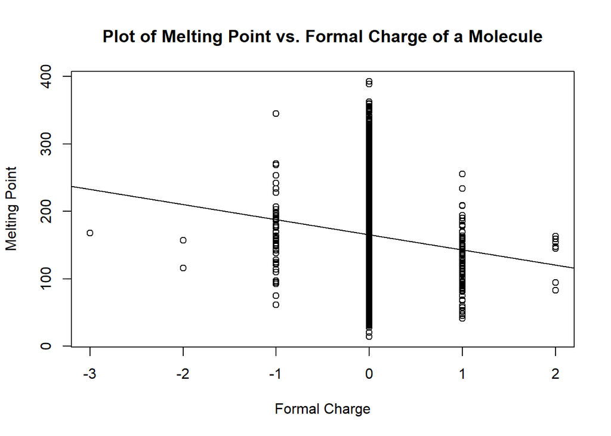

```r
#
# linear regression plots
mpFormalChargeFit <- lm(meltingPoints$mp~meltingPoints$formal.charge)
plot(meltingPoints$formal.charge, meltingPoints$mp,
     main="Plot of Melting Point vs. Formal Charge of a Molecule", xlab = "Formal Charge", ylab = "Melting Point")
abline(mpFormalChargeFit)
```

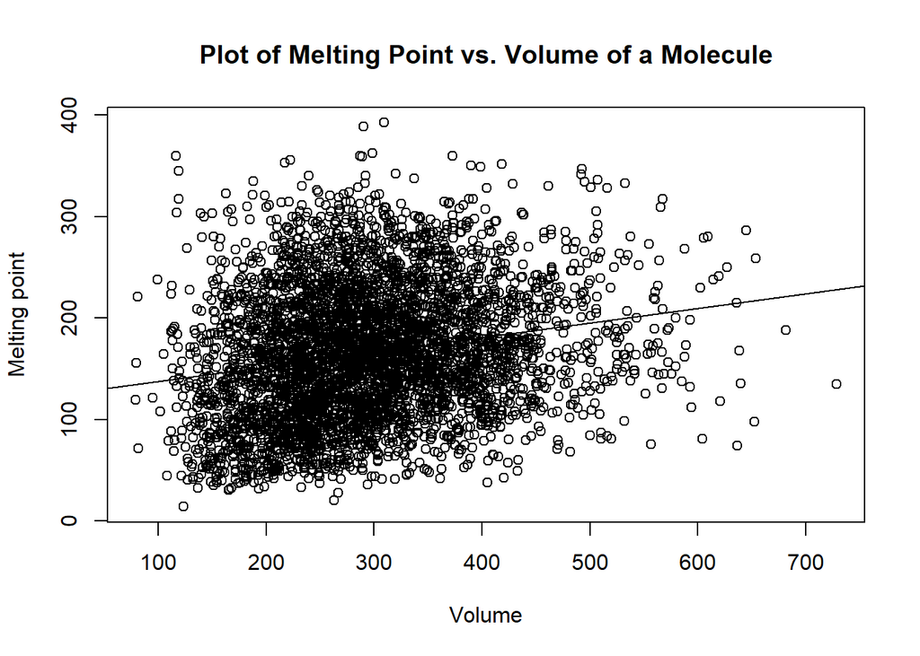

```r
mpVolumeFit <- lm(meltingPoints$mp~meltingPoints$volume)
plot(meltingPoints$volume, meltingPoints$mp,
     main="Plot of Melting Point vs. Volume of a Molecule", xlab = "Volume", ylab = "Melting point")
abline(mpVolumeFit)
```

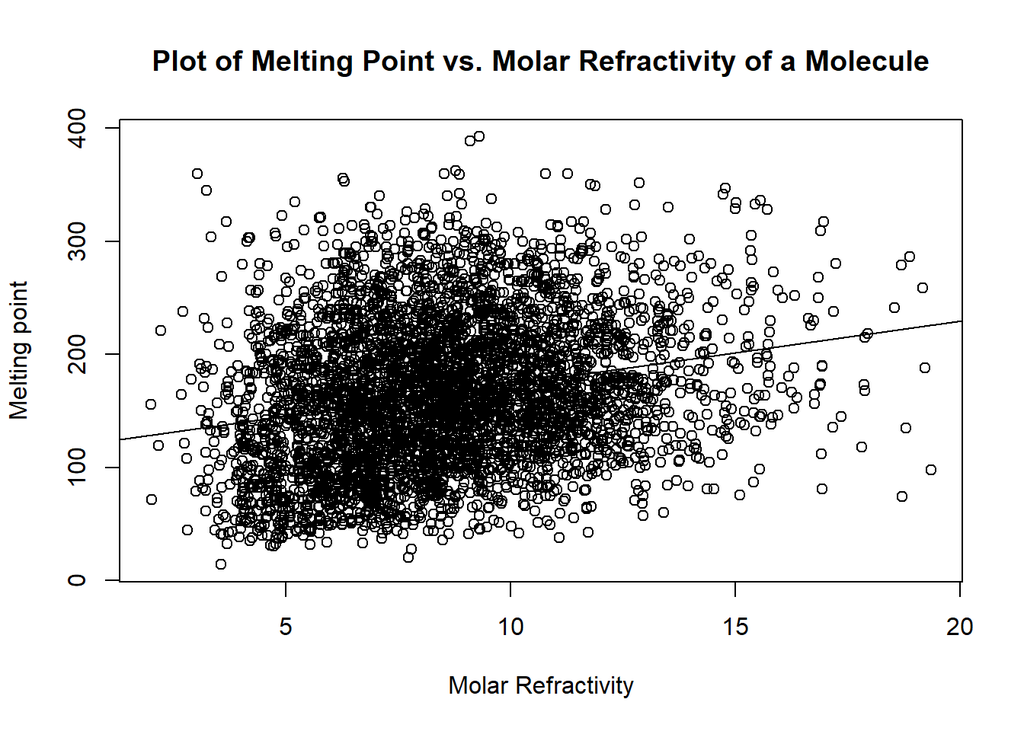

```r
mpRefractivityFit <- lm(meltingPoints$mp~meltingPoints$refractivity)
plot(meltingPoints$refractivity,meltingPoints$mp,
     main="Plot of Melting Point vs. Molar Refractivity of a Molecule", xlab = "Molar Refractivity", ylab = "Melting point")
abline(mpRefractivityFit)
```

## Multiple Linear Regression

A multiple linear regression was done, combining charge, volume, and refractivity, targeting melting point.

```r
#
# Multifit of charge, volume, and refractivty targeting melting point
multiFit <- lm(meltingPoints$mp~meltingPoints$refractivity+meltingPoints$formal.charge+meltingPoints$volume)
summary(multiFit)
```

```
##
## Call:
## lm(formula = meltingPoints$mp ~ meltingPoints$refractivity +
##     meltingPoints$formal.charge + meltingPoints$volume)
##
## Residuals:
##      Min       1Q   Median       3Q      Max
## -151.529  -46.495   -5.889   42.009  230.036
##
## Coefficients:
##                              Estimate Std. Error t value Pr(>|t|)
## (Intercept)                 123.01167    3.10703  39.591  < 2e-16 ***
## meltingPoints$refractivity   29.85526    2.14004  13.951  < 2e-16 ***
## meltingPoints$formal.charge -22.78054    4.33599  -5.254 1.56e-07 ***
## meltingPoints$volume         -0.71869    0.06285 -11.435  < 2e-16 ***
## ---
## Signif. codes:  0 '***' 0.001 '**' 0.01 '*' 0.05 '.' 0.1 ' ' 1
##
## Residual standard error: 61.22 on 4446 degrees of freedom
## Multiple R-squared:  0.0888, Adjusted R-squared:  0.08818
## F-statistic: 144.4 on 3 and 4446 DF,  p-value: < 2.2e-16
```

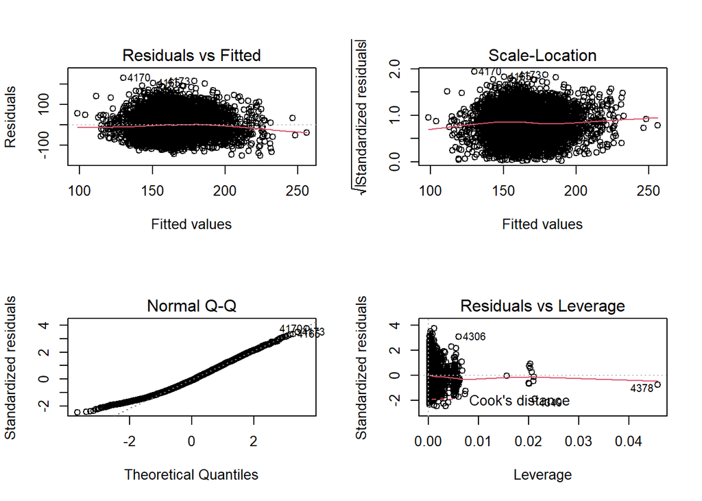

```r
#
# diagnostic plots
layout(matrix(c(1,2,3,4),2,2))
plot(multiFit)
```

## BIC Score Comparison Analysis

Finally, a BIC analysis was done on dipole moment targeting melting point. This is done to check for causation. The BIC score of the dipole moment is 32606 and the BIC score of the dipole moment targeting the melting point is 32557, resulting in a difference of 49. Since this is greater than 10, there is likely to be causation within this relationship.

```r
#
# BIC scores targeted on melting point
# Question: Do the dipole moment and Melting Point have a causal relationship?
BIC(lm(meltingPoints$dipole.moment~1))
```

```
## [1] 32606.69
```

```r
BIC(lm(meltingPoints$dipole.moment~meltingPoints$mp))
```

```
## [1] 32557.61
```

```r
#
# Since the BIC score of the relationship is more
# than 10 less than the BIC score of just the dipole
# moment, then there is likely to be some causation
# between dipole moments and melting points
```